# Laboratorio 01: Análisis Exploratorio de Datos

Santiago Banchero, Juan Fernandez, Eloisa Piccoli

30/03/2021

## Exploración de datos

**Explore y explique en qué consiste el dataset utilizando herramientas de exploración de datos.**  
**a. Releve las características de los atributos.**

Verificamos los nombres de los atributos y sus características con *str*:

```r
MPI_subnational = read.csv('https://raw.githubusercontent.com/dmuba/dmuba.github.io/master/Practicos/LAB01/MPI_subnational.csv', header = TRUE, sep = ',')

# Nombres de variables
names(MPI_subnational)
```

```
## [1] "ISO.country.code"                  "Country"
## [3] "Sub.national.region"               "World.region"
## [5] "MPI.National"                      "MPI.Regional"
## [7] "Headcount.Ratio.Regional"          "Intensity.of.deprivation.Regional"
```

```r
# Caracteristicas de las variables
str(MPI_subnational)
```

```
## 'data.frame':    984 obs. of  8 variables:
##  $ ISO.country.code                 : chr  "AFG" "AFG" "AFG" "AFG" ...
##  $ Country                          : chr  "Afghanistan" "Afghanistan" "Afghanistan" "Afghanistan" ...
##  $ Sub.national.region              : chr  "Badakhshan" "Badghis" "Baghlan" "Balkh" ...
##  $ World.region                     : chr  "South Asia" "South Asia" "South Asia" "South Asia" ...
##  $ MPI.National                     : num  0.295 0.295 0.295 0.295 0.295 0.295 0.295 0.295 0.295 0.295 ...
##  $ MPI.Regional                     : num  0.387 0.466 0.3 0.301 0.325 0.313 0.319 0.25 0.245 0.384 ...
##  $ Headcount.Ratio.Regional         : num  67.5 79.3 59.7 55.7 61 65.1 61.4 49.4 47.4 74.6 ...
##  $ Intensity.of.deprivation.Regional: num  57.3 58.8 50.3 54.1 53.3 48.1 52 50.6 51.6 51.5 ...
```

**b. Represente gráficamente la cantidad de ciudades agrupados por Región.**

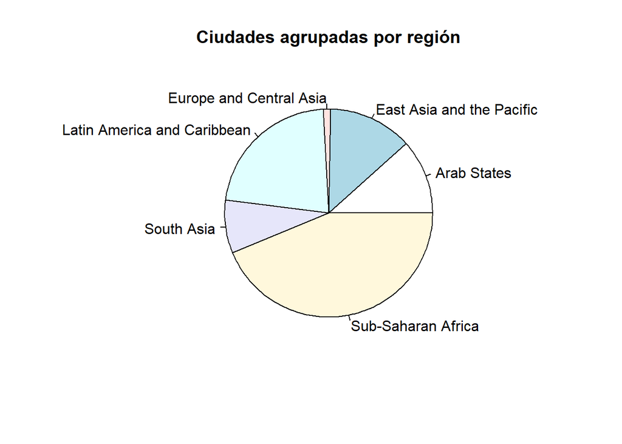

```r
pie(table(MPI_subnational$World.region), main="Ciudades agrupadas por región")
```

## Medidas de posición

**Calcule las medidas de posición para los atributos numéricos y agrupe los cálculos de acuerdo a la Región.**

```r
# Calculo la Media
apply(MPI_subnational[,5:8], 2, mean, na.rm=TRUE)
```

```
##                      MPI.National                      MPI.Regional
##                         0.2041067                         0.2113303
##          Headcount.Ratio.Regional Intensity.of.deprivation.Regional
##                        40.1844512                        47.1809766
```

```r
# Calculo la Mediana
apply(MPI_subnational[,5:8], 2, median, na.rm=TRUE)
```

```
##                      MPI.National                      MPI.Regional
##                             0.174                             0.155
##          Headcount.Ratio.Regional Intensity.of.deprivation.Regional
##                            33.950                            45.600
```

```r
# Calculo de moda
library(modeest)
apply(MPI_subnational[,5:8], 2, mfv, na.rm=TRUE)
```

```
## argument 'na.rm' is soft-deprecated, please start using 'na_rm' instead
## argument 'na.rm' is soft-deprecated, please start using 'na_rm' instead
## argument 'na.rm' is soft-deprecated, please start using 'na_rm' instead
## argument 'na.rm' is soft-deprecated, please start using 'na_rm' instead
```

```
## $MPI.National
## [1] 0.066 0.303
##
## $MPI.Regional
## [1] 0.006
##
## $Headcount.Ratio.Regional
## [1] 6.5
##
## $Intensity.of.deprivation.Regional
## [1] 41.9 42.7
```

### Cálculos agrupados por región

Se define un ejemplo de una medida de posición (media) agrupada por región:

```r
# Agrupando por Región
aggregate(MPI.National ~ World.region, data=MPI_subnational, FUN=mean)
```

```
##                  World.region MPI.National
## 1                 Arab States   0.11078261
## 2   East Asia and the Pacific   0.12432812
## 3     Europe and Central Asia   0.02890909
## 4 Latin America and Caribbean   0.05427064
## 5                  South Asia   0.20904938
## 6          Sub-Saharan Africa   0.33203016
```

**a. Ordene los resultados del MPI resultante y concluya al respecto. Help(order).**

```r
# Por país
MPI_x_WR=aggregate(MPI.National ~ World.region, data=MPI_subnational, FUN=mean)
# Ranking
MPI_x_WR[order(-MPI_x_WR$MPI.National),]
```

```
##                  World.region MPI.National
## 6          Sub-Saharan Africa   0.33203016
## 5                  South Asia   0.20904938
## 2   East Asia and the Pacific   0.12432812
## 1                 Arab States   0.11078261
## 4 Latin America and Caribbean   0.05427064
## 3     Europe and Central Asia   0.02890909
```

En función del MPI (Multidimensional Poverty Measures) ordenado de forma descendente se puede concluir respecto a la pobreza promedio por región. En función de ello, se observa que la región mundial con mayores índices de pobreza en función de la métrica MPI es Sub-Saharan Africa con 0.33, seguida por South Asia, con 0.20. Para el resto de las regiones mundiales el indicador varía entre 0.12 y 0.02 que es el menor valor (observado para Europe and Central Asia).

**b. Grafique las variables y observe su comportamiento (graph: barplot, pie & hist).**  
Ejemplo de variable continua:

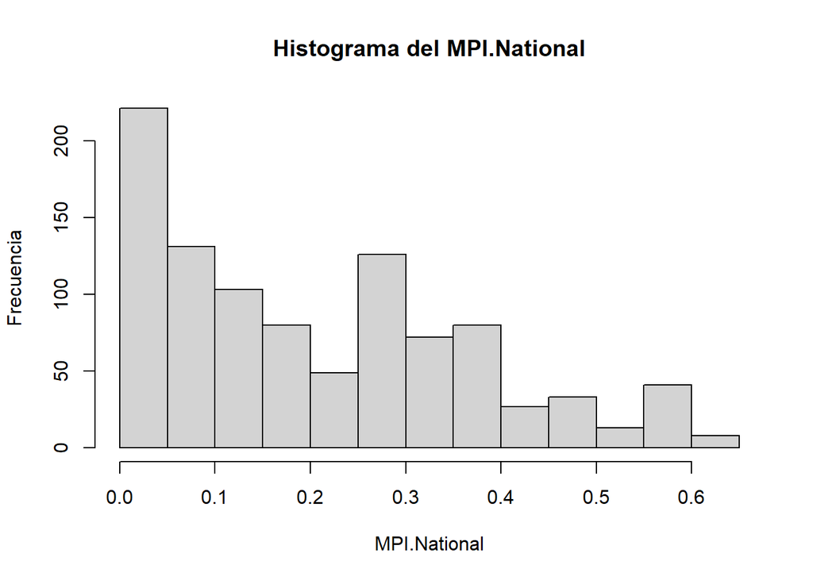

```r
hist(MPI_subnational$MPI.National, main = "Histograma del MPI.National", xlab = "MPI.National", ylab = "Frecuencia")
```

El histograma de la variable MPI.National permite ver que una gran proporción de los valores se encuentran entre 0 y 0.1. Luego, es posible observar que existe una nueva concentración de observaciones en torno 0.25-0.4, por encima de esos valores la cantidad de observaciones disminuye.  
Ejemplo de variable discreta:

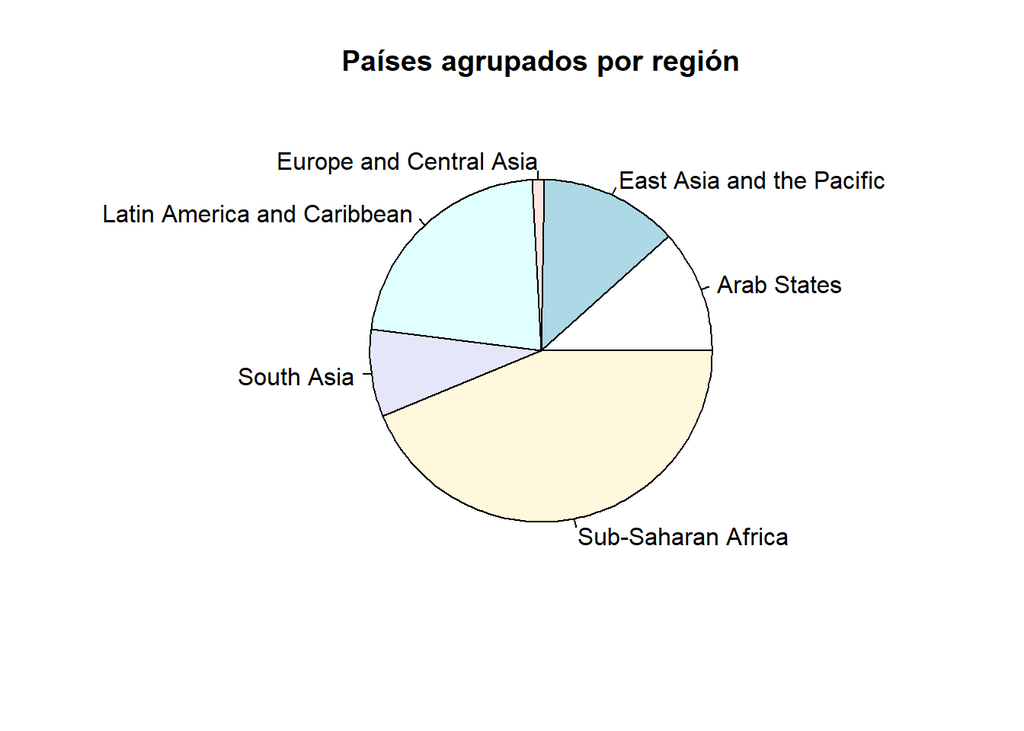

```r
pie(table(MPI_subnational$World.region), main="Países agrupados por región")
```

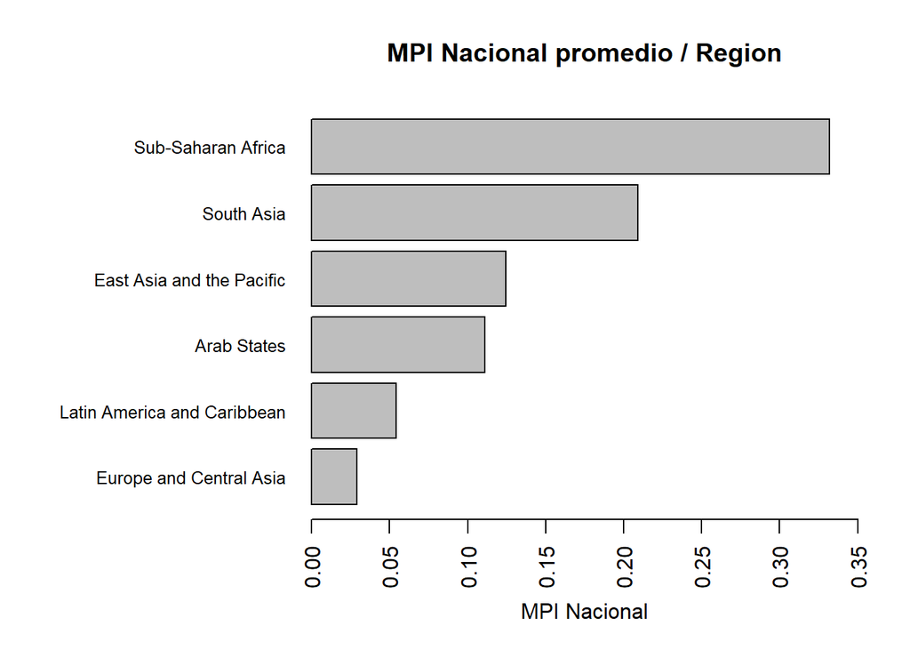

```r
# Genera un Data Frame con Región y MPI National promedio
df.agg = aggregate(MPI.National ~ World.region, data=MPI_subnational, FUN=mean)
# Ordenamos por MPI
data = df.agg[order(df.agg$MPI.National, decreasing = F),]
# Configuramos parámetros del lienzo donde se va a plotear
# principalmente el margen izquierdo (el valor 12) para que entren los nombres
# de las regiones
par(mfrow=c(1, 1), mar=c(5, 12, 4, 2) )
barplot(height = data$MPI.National,
        names.arg = data$World.region,
        main="MPI Nacional promedio / Region",
        las=2,
        cex.names = 0.80,
        xlim=c(0,0.35),
        xlab = "MPI Nacional",
        horiz = T)
```

## Medidas de dispersión

**Calcular el desvío estándar, la varianza y el rango para cada una de las variables.**

Cálculo del *desvío estandar* para cada atributo numérico:

```r
apply(MPI_subnational[,5:8], 2, sd, na.rm=TRUE)
```

```
##                      MPI.National                      MPI.Regional
##                         0.1602476                         0.1836210
##          Headcount.Ratio.Regional Intensity.of.deprivation.Regional
##                        29.9814031                         8.0472253
```

Cálculo de la *varianza* para cada atributo numérico:

```r
apply(MPI_subnational[,5:8], 2, var, na.rm=TRUE)
```

```
##                      MPI.National                      MPI.Regional
##                        0.02567929                        0.03371667
##          Headcount.Ratio.Regional Intensity.of.deprivation.Regional
##                      898.88452910                       64.75783530
```

Cálculo del *rango* para cada atributo numérico:

```r
apply(MPI_subnational[,5:8], 2, range, na.rm=TRUE)
```

```
##      MPI.National MPI.Regional Headcount.Ratio.Regional
## [1,]        0.006        0.000                        0
## [2,]        0.605        0.744                       99
##      Intensity.of.deprivation.Regional
## [1,]                              33.3
## [2,]                              75.9
```

Cálculo del *Coeficiente de Variación* para cada atributo numérico (mediante la función cv del paquete statip):

```r
apply(MPI_subnational[,5:8], 2, statip::cv, na_rm=TRUE)
```

```
##                      MPI.National                      MPI.Regional
##                         0.7851167                         0.8688816
##          Headcount.Ratio.Regional Intensity.of.deprivation.Regional
##                         0.7460946                         0.1705608
```

También puede ser calculado usando una función propia:

```r
apply(MPI_subnational[,5:8], 2, FUN = function(x) sd(x,na.rm=TRUE)/mean(x, na.rm=TRUE))
```

```
##                      MPI.National                      MPI.Regional
##                         0.7851167                         0.8688816
##          Headcount.Ratio.Regional Intensity.of.deprivation.Regional
##                         0.7460946                         0.1705608
```

**a. Realice diagramas de cajas y scatterplot’s. Documente las conclusiones.**

### Diagramas de cajas:

```r
boxplot(MPI_subnational[,5:6], main="Boxplot de MPI National y Regional")
```

[output not shown]

[figure not shown]

En este boxplot puede observarse que la distribución de Headcount.Ratio.Regional presenta se distribuyen de manera homogénea en torno a la mediana registrando un leve sesgo hacia la derecha, sus valores varían entre 0-100 y no se observan valores atípicos (o por fuera de +/-1.5*IQR). En cambio, la variable Intensity.of.deprivation.Regional posee una distribución compacta concentrada en torno a la mediana con sus datos concentrados entre 35-65 aproximadamente. Además, registra presencia de valores atípicos en el extremo superior de la distribución.

### Gráficos de dispersión:

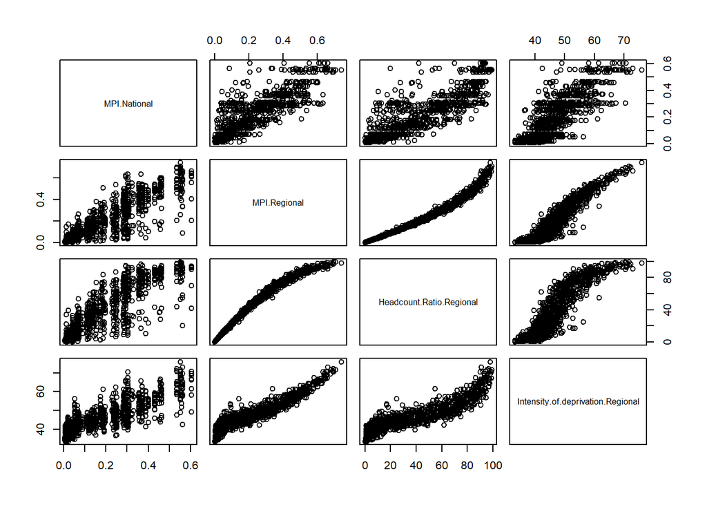

**b. ¿Qué variable es la que presenta mayor dispersión? Tenga en cuenta que cada variable puede estar expresada en diferentes unidades y magnitudes.**

Dada la diferencia de magnitudes se utilizó el Coeficiente de Variación, este muestra que la mayor variación porcentual se adjudica a MPI.Regional (con ~86.8%), es seguida por MPI.Nacional (~78.5%), en tercer lugar Headcount.Ratio.Regional (~74.6%) y por último Intensity.of.deprivation.Regional (~17%). Esto es coherente con lo observado en los gráficos de cajas donde los bigotes más amplios son los de la variable MPI.Regional y la distribución más compacta es Intensity.of.deprivation.Regional.

## Medidas de asociación

**Calcular el coeficiente de correlación de todas las variables y explique el resultado.**

```r
matriz.correlaciones = cor(MPI_subnational[,5:8], use = "complete.obs")
colnames(matriz.correlaciones)=c("MPI.Nat","MPI.Reg","Headcount.Reg","Intensity.Reg")
rownames(matriz.correlaciones)=c("MPI.Nat","MPI.Reg","Headcount.Reg","Intensity.Reg")
print(matriz.correlaciones)
```

```
##                 MPI.Nat   MPI.Reg Headcount.Reg Intensity.Reg
## MPI.Nat       1.0000000 0.8589756     0.8554401     0.8136333
## MPI.Reg       0.8589756 1.0000000     0.9839708     0.9446785
## Headcount.Reg 0.8554401 0.9839708     1.0000000     0.9029842
## Intensity.Reg 0.8136333 0.9446785     0.9029842     1.0000000
```

Como puede observarse en el cálculo del coeficiente de correlación de Pearson, todas las variables tienen una correlación positiva alta entre sí, observando coeficientes de correlación entre 0.81 y 0.98.

**¿Qué tipo de gráficos describen mejor esta relación entre las variables?**